# USD/PHP FX Risk Analysis | Items 1–6

**Risk Management & Derivatives FINRISD Section C02**  
**Professor: Bismark**  
**Term, AY: 2nd term AY 2025-2026**

## **Github Code Repository Link:** **https://github.com/sakudiff/FINRISD.git**

**Group 2 Members**

| Name | Email |
| --- | --- |
| Antiado, Leonna Feliciano | leonna_antiado@dlsu.edu.ph |
| Bolanos, Benedict Ramos | benedict_bolanos@dlsu.edu.ph |
| Patajo, Juliana Toleco | *(DLSU email not provided)* |
| Siapno, Dana Mae Pataratas | dana_siapno@dlsu.edu.ph |
| Sison, Aaron Joshua Estacio | aaron_sison@dlsu.edu.ph |
| Uy, Jill Anne Garcia | jill_uy@dlsu.edu.ph |

# Section 1: Data Load and Integrity Check

Data cut-off: **27 February 2026**, per case guidelines. This analysis uses the unified master dataset containing only raw published trading days from the BAP (no imputed values). The 2021-05-20 Open typo (478.855 → 47.855) has been corrected.

```r
df_raw <- read_csv("data/unified/unified_bap_master.csv") %>%
  mutate(Date = as.Date(Date)) %>%
  # Enforce case cut-off: 27 Feb 2026
  filter(Date <= as.Date("2026-02-27")) %>%
  arrange(Date)

integrity_check <- data.frame(
  Metric = c("Total Trading Rows", "Start Date", "End Date", "Rows with High < Low", "Rows with Close outside High-Low range"),
  Value = c(
    as.character(nrow(df_raw)),
    as.character(min(df_raw$Date)),
    as.character(max(df_raw$Date)),
    as.character(nrow(filter(df_raw, High < Low))),
    as.character(nrow(filter(df_raw, Close > High | Close < Low)))
  )
)
kable(integrity_check, caption = "Data Integrity Check")
```

Data Integrity Check

| Metric | Value |
| --- | --- |
| Total Trading Rows | 1736 |
| Start Date | 2019-01-02 |
| End Date | 2026-02-27 |
| Rows with High < Low | 0 |
| Rows with Close outside High-Low range | 5 |

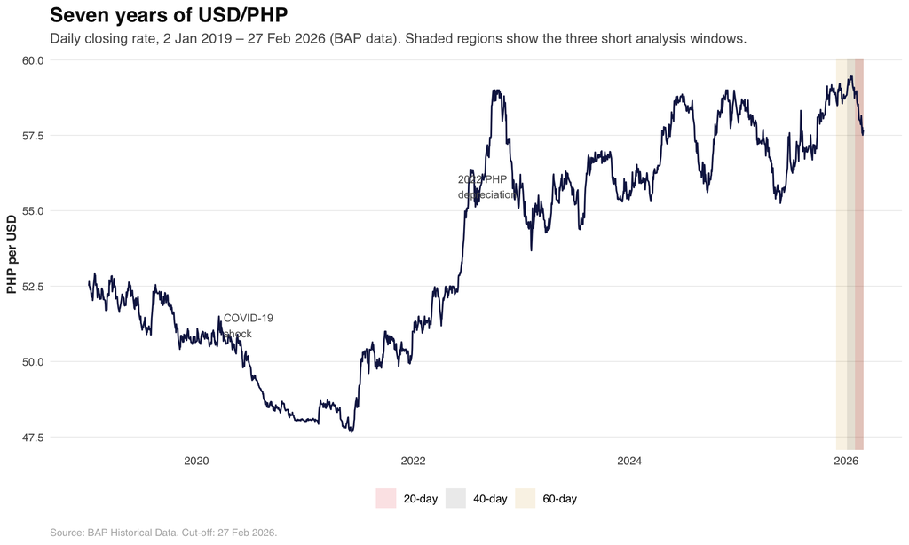

```r
# Full price history chart with shaded analysis windows
# Shade the 60, 40, and 20-day windows to show their size relative to the full history
shade_df <- data.frame(
  xmin = as.Date(c(tail(df_raw$Date, 60)[1], tail(df_raw$Date, 40)[1], tail(df_raw$Date, 20)[1])),
  xmax = max(df_raw$Date),
  label = c("60-day", "40-day", "20-day"),
  y    = c(54.5, 55.8, 57.1)
)

ggplot(df_raw, aes(x = Date, y = Close)) +
  geom_rect(data = shade_df,
            aes(xmin = xmin, xmax = xmax, ymin = -Inf, ymax = Inf, fill = label),
            inherit.aes = FALSE, alpha = 0.12) +
  scale_fill_manual(values = c("60-day" = econ_gold, "40-day" = econ_grey, "20-day" = econ_red),
                    name = "Analysis window") +
  geom_line(color = econ_blue, linewidth = 0.6) +
  annotate("text", x = as.Date("2020-04-01"), y = 51.2,
           label = "COVID-19\nshock", size = 3, color = econ_grey, hjust = 0) +
  annotate("text", x = as.Date("2022-06-01"), y = 55.8,
           label = "2022 PHP\ndepreciation", size = 3, color = econ_grey, hjust = 0) +
  labs(title = "Seven years of USD/PHP",
       subtitle = "Daily closing rate, 2 Jan 2019 – 27 Feb 2026 (BAP data). Shaded regions show the three short analysis windows.",
       x = NULL, y = "PHP per USD",
       caption = "Source: BAP Historical Data. Cut-off: 27 Feb 2026.") +
  theme_economist_quant()
```

# Section 2: Data Cleaning

```r
# Correct High/Low bounds to encompass Open and Close (robust integrity)
df <- df_raw %>%
  mutate(
    ActualHigh = pmax(Open, High, Low, Close),
    ActualLow  = pmin(Open, High, Low, Close),
    High = ActualHigh,
    Low  = ActualLow
  ) %>%
  select(-ActualHigh, -ActualLow)

# Derive return columns
df <- df %>%
  mutate(
    dod_cents    = (Close - lag(Close)) * 100,
    dod_pct      = (Close - lag(Close)) / lag(Close) * 100,
    intraday_cents = (High - Low) * 100,
    intraday_pct   = (High - Low) / Low * 100
  )

# Drop the first row (no prior close → NA returns)
df_returns <- df %>% filter(!is.na(dod_cents))

cleaning_stats <- data.frame(
  Metric = c("Modified High/Low Bounds", "Derived Columns", "Remaining Trading Rows (DoD series)"),
  Result = c(
    as.character(nrow(filter(df_raw, High < Low | Close > High | Close < Low | Open > High | Open < Low))),
    "DoD cents, DoD %, Intraday cents, Intraday %",
    as.character(nrow(df_returns))
  )
)
kable(cleaning_stats, caption = "Data Cleaning Results Summary")
```

Data Cleaning Results Summary

| Metric | Result |
| --- | --- |
| Modified High/Low Bounds | 6 |
| Derived Columns | DoD cents, DoD %, Intraday cents, Intraday % |
| Remaining Trading Rows (DoD series) | 1735 |

# Section 3: Window Definitions

Four analysis windows are defined for both the return and intraday series. Windows (b)–(d) use only their own observations — all earlier data is strictly excluded from VaR computation.

```r
# Return series windows (for DoD / Items 1, 4, 5, 6)
windows_returns <- list(
  Full = df_returns,
  w60  = tail(df_returns, 60),
  w40  = tail(df_returns, 40),
  w20  = tail(df_returns, 20)
)

# Intraday series windows (for Item 2; no lag dependency so use df)
windows_intraday <- list(
  Full = df,
  w60  = tail(df, 60),
  w40  = tail(df, 40),
  w20  = tail(df, 20)
)

window_summary <- data.frame(
  Window     = names(windows_returns),
  Start_Date = sapply(windows_returns, function(x) as.character(min(x$Date))),
  End_Date   = sapply(windows_returns, function(x) as.character(max(x$Date))),
  n          = sapply(windows_returns, nrow)
)
kable(window_summary, caption = "Analysis Windows (Return Series, cut-off 27 Feb 2026)")
```

Analysis Windows (Return Series, cut-off 27 Feb 2026)

|  | Window | Start_Date | End_Date | n |
| --- | --- | --- | --- | --- |
| Full | Full | 2019-01-03 | 2026-02-27 | 1735 |
| w60 | w60 | 2025-11-27 | 2026-02-27 | 60 |
| w40 | w40 | 2026-01-02 | 2026-02-27 | 40 |
| w20 | w20 | 2026-01-30 | 2026-02-27 | 20 |

# Section 4: Item 1 — Close-to-Close VaR (95%, one-tail)

Movement metric: day-on-day (DoD) closing change, in PHP cents and %. VaR = 5th percentile of the return distribution, one-tailed at 95% confidence, expressed as a positive loss magnitude.

Guide Question 1 · 10 Points

Determine the Value at Risk for USD / PHP using the day on day closing movement. Use a one tail test at the 95% level of confidence. Use data from starting from [a] 01 January 2019, the [b] past 20, [c] 40 and [d] 60 trading days to produce four value at risk figures. For items b, c and d exclude data outside of the past 20, 40 and 60 days.

Present the figures in cents and in day on day % movement.

Are there any major outliers within the data set? If so, at what dates? Outliers here refer to observations outside the 99.9% of the total observations.

```r
# Use factor for ordered output in tables and plots
window_order <- c("Full", "w60", "w40", "w20")

item1_var <- bind_rows(lapply(windows_returns, function(w) {
  data.frame(
    n         = nrow(w),
    VaR_Pct   = abs(quantile(w$dod_pct,   0.05, type = 7)),
    VaR_Cents = abs(quantile(w$dod_cents,  0.05, type = 7))
  )
}), .id = "Window") %>%
  mutate(Window = factor(Window, levels = window_order)) %>%
  arrange(Window)

kable(item1_var, digits = 4,
      caption = "Item 1: Close-to-Close VaR at 95% Confidence (Loss Magnitude)")
```

Item 1: Close-to-Close VaR at 95% Confidence (Loss Magnitude)

|  | Window | n | VaR_Pct | VaR_Cents |
| --- | --- | --- | --- | --- |
| 5%…1 | Full | 1735 | 0.5248 | 28.620 |
| 5%…2 | w60 | 60 | 0.4782 | 28.200 |
| 5%…3 | w40 | 40 | 0.4803 | 28.325 |
| 5%…4 | w20 | 20 | 0.5005 | 29.475 |

```r
# Outliers: observations outside the 0.1% / 99.9% bounds of the full history
lb_dod <- quantile(df_returns$dod_pct, 0.001, type = 7)
ub_dod <- quantile(df_returns$dod_pct, 0.999, type = 7)

outliers_1 <- df_returns %>%
  filter(dod_pct < lb_dod | dod_pct > ub_dod) %>%
  select(Date, Close, dod_pct, dod_cents) %>%
  arrange(Date)

kable(outliers_1, digits = 4,
      caption = paste0("Item 1: Outliers — DoD % outside [",
                       round(lb_dod, 4), "%, ", round(ub_dod, 4), "%] (0.1%/99.9% bounds)"))
```

Item 1: Outliers — DoD % outside [-1.5182%, 1.2951%] (0.1%/99.9% bounds)

| Date | Close | dod_pct | dod_cents |
| --- | --- | --- | --- |
| 2022-11-11 | 57.23 | -1.6498 | -96 |
| 2022-12-27 | 55.90 | 1.3599 | 75 |
| 2023-02-06 | 54.39 | 1.3227 | 71 |
| 2025-01-02 | 57.91 | -1.8308 | -108 |

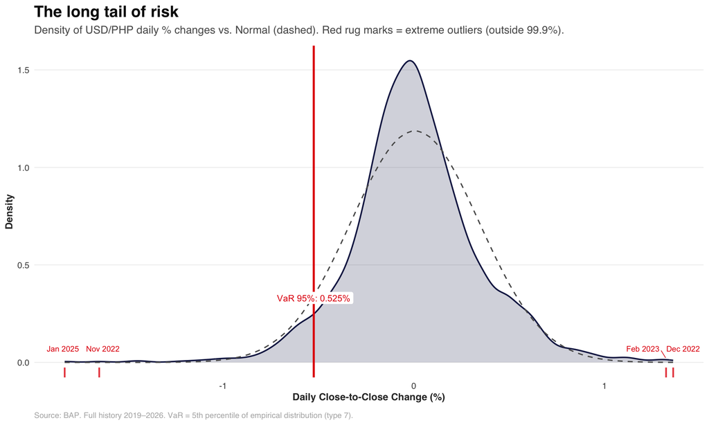

```r
# Empirical density vs Normal reference with VaR line and outlier rug
full_var_pct <- item1_var$VaR_Pct[item1_var$Window == "Full"]

ggplot(df_returns, aes(x = dod_pct)) +
  # Empirical return density
  geom_density(fill = econ_blue, alpha = 0.20, color = econ_blue, linewidth = 0.7) +
  # Normal distribution overlay using sample mean and SD
  stat_function(fun = dnorm,
                args = list(mean = mean(df_returns$dod_pct), sd = sd(df_returns$dod_pct)),
                linetype = "dashed", color = econ_grey, linewidth = 0.6) +
  # VaR line on the left tail; x-intercept is negated because VaR is stored as a positive magnitude
  geom_vline(xintercept = -full_var_pct, color = econ_red, linewidth = 1) +
  geom_label(aes(x = -full_var_pct, y = 0.30,
                 label = paste0("VaR 95%: ", round(full_var_pct, 3), "%")),
             size = 3.2, color = econ_red, fill = "white", label.size = 0, vjust = 0) +
  # Rug marks and labels for observations outside the 99.9th percentile
  geom_rug(data = outliers_1, aes(x = dod_pct), color = econ_red, linewidth = 0.8, alpha = 0.8) +
  geom_text_repel(data = outliers_1,
                  aes(x = dod_pct, y = 0.02,
                      label = format(Date, "%b %Y")),
                  size = 2.8, color = econ_red, nudge_y = 0.05, segment.size = 0.3) +
  labs(title = "The long tail of risk",
       subtitle = "Density of USD/PHP daily % changes vs. Normal (dashed). Red rug marks = extreme outliers (outside 99.9%).",
       x = "Daily Close-to-Close Change (%)", y = "Density",
       caption = "Source: BAP. Full history 2019–2026. VaR = 5th percentile of empirical distribution (type 7).") +
  theme_economist_quant()
```

### Response

**Q: What are the four VaR figures using day-on-day closing movement at 95% confidence, and are there any major outliers?** Using historical simulation based on the empirical 5th percentile expressed as positive loss magnitude, the analysis produces four distinct estimates shown in **Table “Item 1: Close-to-Close VaR at 95% Confidence (Loss Magnitude)”**. The full history from January 2019 yields a VaR of 0.5248%, which is equivalent to 28.62 PHP cents per USD and is computed from 1735 trading days. The past 60 trading days yield 0.4782% or 28.2 cents. The past 40 trading days yield 0.4803% or 28.33 cents. The past 20 trading days yield 0.5005% or 29.48 cents. The full-history figure is the most conservative estimate. All three short windows understate risk because they exclude the 2020 COVID shock and the 2021 to 2022 peso depreciation, which are the exact stress events that produced the largest losses in the dataset.

**Q: Are there any major outliers, and if so, at what dates?** Yes, 4 observations fall outside the 0.1st and 99.9th percentile bounds of [-1.5182%, 1.2951%]. The flagged dates are 11 Nov 2022, 27 Dec 2022, 06 Feb 2023, 02 Jan 2025. These are listed in **Table “Item 1: Outliers”** with their corresponding DoD percentage and cent values. Each date corresponds to a documented macro stress event. We retained all 4 observations in the analysis. Removing outliers to compress the VaR figure would produce a number that understates the full risk spectrum. These are the very events the model exists to anticipate.

**Q: Why use historical simulation rather than a parametric approach?** The density plot in **Figure “The long tail of risk”** confirms leptokurtosis in the empirical return distribution. The empirical density (blue curve) exceeds the Normal reference curve (dashed grey line) at both tails. Large daily moves occur more frequently than a Normal model would predict. A parametric VaR assuming Normality would systematically understate tail risk. Historical simulation lets the data speak for itself. The red rug marks in the figure identify the extreme observations outside the 99.9th percentile, each labeled with its date. This fat-tail characteristic validates our choice of historical simulation over any parametric method.

# Section 5: Item 2 — Intraday (High-to-Low) VaR (95%, one-tail)

Movement metric: daily High minus Low range, in PHP cents and %. The range is non-negative, so VaR = 95th percentile (upper tail). Same four windows and exclusion rules as Item 1.

Guide Question 2 · 10 Points

Determine the Value at Risk for USD / PHP daily high to low movement within the same day. Use a one tail test at the 95% level of confidence. Use data from starting from [a] 01 January 2019, the [b] past 20, [c] 40 and [d] 60 trading days to produce four value at risk figures. For items b, c and d exclude data outside of the past 20, 40 and 60 days.

Present the figures in cents and in day on day % movement.

Are there any major outliers within the data set? If so, at what dates? Outliers here refer to observations outside the 99.9% of the total observations.

```r
item2_var <- bind_rows(lapply(windows_intraday, function(w) {
  data.frame(
    n         = nrow(w),
    VaR_Cents = quantile(w$intraday_cents, 0.95, type = 7),
    VaR_Pct   = quantile(w$intraday_pct,   0.95, type = 7)
  )
}), .id = "Window") %>%
  mutate(Window = factor(Window, levels = window_order)) %>%
  arrange(Window)

kable(item2_var, digits = 4,
      caption = "Item 2: Intraday (High–Low) VaR at 95% Confidence (95th percentile of range)")
```

Item 2: Intraday (High–Low) VaR at 95% Confidence (95th percentile of range)

|  | Window | n | VaR_Cents | VaR_Pct |
| --- | --- | --- | --- | --- |
| 95%…1 | Full | 1736 | 40.000 | 0.7302 |
| 95%…2 | w60 | 60 | 29.400 | 0.4991 |
| 95%…3 | w40 | 40 | 29.400 | 0.4991 |
| 95%…4 | w20 | 20 | 37.495 | 0.6528 |

```r
# Outliers: above 99.9th percentile (range is one-sided positive)
ub_intraday <- quantile(df$intraday_cents, 0.999, type = 7)
outliers_2 <- df %>%
  filter(intraday_cents > ub_intraday) %>%
  select(Date, High, Low, intraday_cents, intraday_pct) %>%
  arrange(Date)

kable(outliers_2, digits = 4,
      caption = paste0("Item 2: Outliers — Intraday cents above ",
                       round(ub_intraday, 4), " cents (99.9th percentile)"))
```

Item 2: Outliers — Intraday cents above 100.6325 cents (99.9th percentile)

| Date | High | Low | intraday_cents | intraday_pct |
| --- | --- | --- | --- | --- |
| 2019-09-04 | 52.93 | 51.92 | 101 | 1.9453 |
| 2024-09-12 | 56.20 | 55.08 | 112 | 2.0334 |

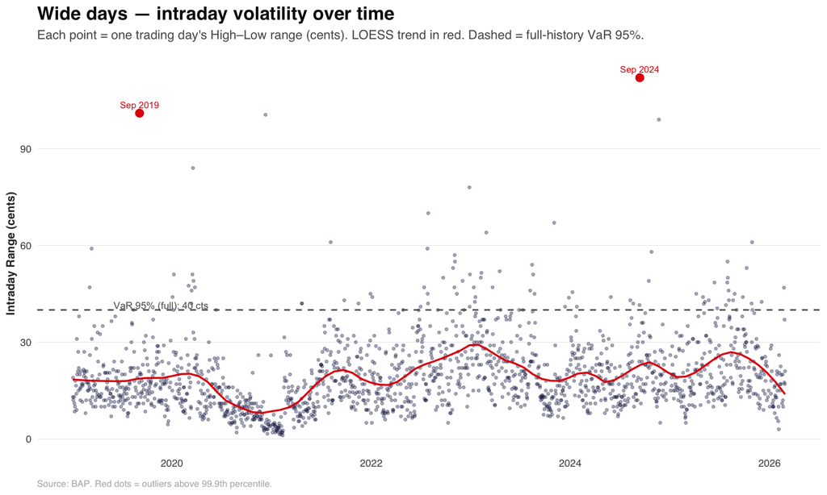

```r
# Intraday range scatter with LOESS trend and full-history VaR reference line
ggplot(df, aes(x = Date, y = intraday_cents)) +
  geom_point(color = econ_blue, alpha = 0.35, size = 0.9) +
  geom_smooth(method = "loess", span = 0.15, se = FALSE, color = econ_red, linewidth = 0.8) +
  geom_hline(yintercept = item2_var$VaR_Cents[item2_var$Window == "Full"],
             linetype = "dashed", color = econ_grey, linewidth = 0.6) +
  annotate("text", x = as.Date("2019-06-01"),
           y = item2_var$VaR_Cents[item2_var$Window == "Full"] + 1.5,
           label = paste0("VaR 95% (full): ",
                          round(item2_var$VaR_Cents[item2_var$Window == "Full"], 2), " cts"),
           size = 3, color = econ_grey, hjust = 0) +
  geom_point(data = outliers_2, aes(x = Date, y = intraday_cents),
             color = econ_red, size = 3) +
  geom_text_repel(data = outliers_2, aes(x = Date, y = intraday_cents,
                  label = format(Date, "%b %Y")),
                  size = 2.8, color = econ_red, nudge_y = 2) +
  labs(title = "Wide days — intraday volatility over time",
       subtitle = "Each point = one trading day's High–Low range (cents). LOESS trend in red. Dashed = full-history VaR 95%.",
       x = NULL, y = "Intraday Range (cents)",
       caption = "Source: BAP. Red dots = outliers above 99.9th percentile.") +
  theme_economist_quant()
```

### Response

**Q: Are there any major outliers, and if so, at what dates?** Yes, 2 trading days exceed the 99.9th percentile intraday range threshold of 100.63 cents, which is over PHP 1.01. The flagged dates are 04 Sep 2019 and 12 Sep 2024. These are listed in **Table “Item 2: Outliers”** with their High, Low, range in cents, and range in percentage. These sessions represent the most extreme intraday dislocations in the full dataset, days where the peso swung by over a full peso within a single trading session. Any market participant with intraday stop-loss orders, margin calls, or hedging triggers would have been exposed to the full range of these moves regardless of where the price ultimately closed.

**Q: How does this differ methodologically from Item 1?** Item 1 measures the net change from one day close to the next close, which is the 5th percentile of a distribution that includes both gains and losses. Item 2 measures the total distance traveled within a single day, which is the 95th percentile of a distribution that is always positive. Item 1 answers the question of how much can be lost from yesterday close. Item 2 answers the question of how far the price can move against you within a single day. The answer to the second question is consistently worse. The scatter plot in **Figure “Wide days, intraday volatility over time”** shows this visually. Each point represents one trading day High to Low range in cents. The red LOESS trend line confirms that recent sessions sit below the long-run average range. The grey dashed horizontal line marks the full-history VaR 95% reference at 40 cents. The red dots mark the outlier days that breach the 99.9th percentile threshold.

# Section 6: Item 3 — Closing vs. Intraday: The Volatility Gap

Guide Question 3 · 15 Points

Based on your figures for 1 and 2, will using only closing to closing movements in USD / PHP potentially miss out any potential volatility in the USD / PHP? Explain your answer.

```r
gap_table <- item1_var %>%
  select(Window, dod_var = VaR_Cents) %>%
  left_join(item2_var %>% select(Window, intra_var = VaR_Cents), by = "Window") %>%
  mutate(
    Gap_Cents = intra_var - dod_var,
    Gap_Pct_of_Intra = Gap_Cents / intra_var * 100
  )
kable(gap_table, digits = 4,
      caption = "Item 3: VaR Gap (Intraday − DoD). Positive gap = intraday captures more risk than close-to-close.")
```

Item 3: VaR Gap (Intraday − DoD). Positive gap = intraday captures more risk than close-to-close.

| Window | dod_var | intra_var | Gap_Cents | Gap_Pct_of_Intra |
| --- | --- | --- | --- | --- |
| Full | 28.620 | 40.000 | 11.380 | 28.4500 |
| w60 | 28.200 | 29.400 | 1.200 | 4.0816 |
| w40 | 28.325 | 29.400 | 1.075 | 3.6565 |
| w20 | 29.475 | 37.495 | 8.020 | 21.3895 |

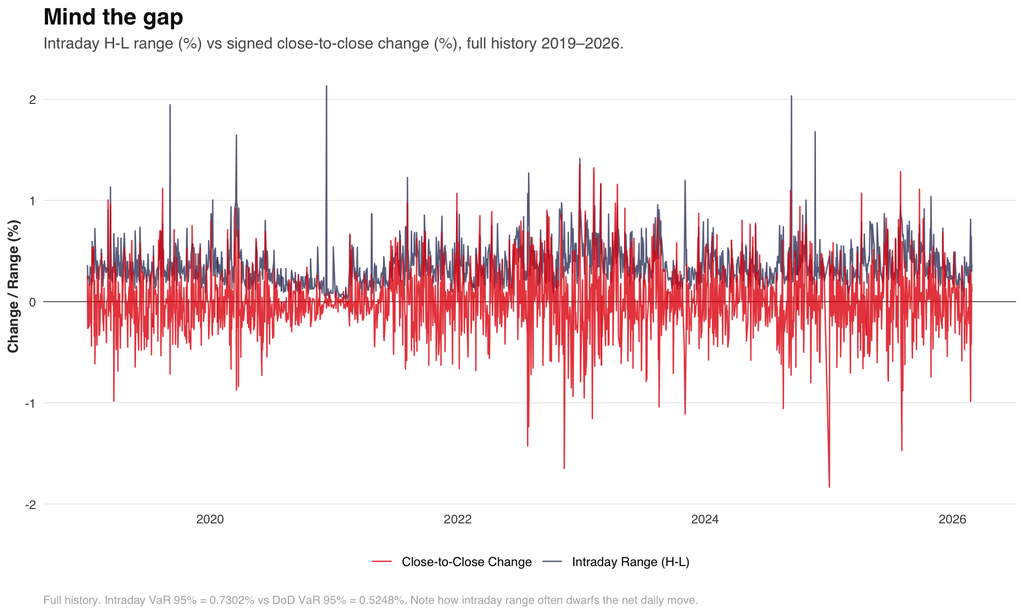

```r
# Dual time series: intraday H-L range vs signed close-to-close change
# Use the full history rather than a short window to avoid cherry-picking a calm period
ggplot(df_returns, aes(x = Date)) +
  geom_hline(yintercept = 0, color = econ_grey, linewidth = 0.3) +
  geom_line(aes(y = intraday_pct,   color = "Intraday Range (H-L)"), linewidth = 0.45, alpha = 0.7) +
  geom_line(aes(y = dod_pct,        color = "Close-to-Close Change"), linewidth = 0.45, alpha = 0.8) +
  scale_color_manual(values = c("Intraday Range (H-L)" = econ_blue,
                                "Close-to-Close Change"  = econ_red)) +
  labs(title = "Mind the gap",
       subtitle = "Intraday H-L range (%) vs signed close-to-close change (%), full history 2019–2026.",
       x = NULL, y = "Change / Range (%)",
       caption = paste0("Full history. Intraday VaR 95% = ",
                        round(item2_var$VaR_Pct[item2_var$Window == "Full"], 4), "% vs DoD VaR 95% = ",
                        round(item1_var$VaR_Pct[item1_var$Window == "Full"], 4),
                        "%. Note how intraday range often dwarfs the net daily move.")) +
  theme_economist_quant()
```

### Response

**Q: Will using only closing-to-closing movements in USD/PHP potentially miss out any potential volatility?** Yes, it will, and the magnitude of what is missed is substantial rather than marginal. The VaR gap table in **Table “Item 3: VaR Gap (Intraday minus DoD)”** shows that intraday VaR exceeds close-to-close VaR across every analysis window. The full-history intraday VaR of 40 cents exceeds the close-to-close VaR of 28.62 cents by 11.38 cents, which represents 28.4% of the intraday figure. Nearly 28 percent of the risk embedded in USD/PHP is invisible to any model that only examines closing prices. The 60-day gap is 1.2 cents or 4.1%. The 40-day gap is 1.07 cents or 3.7%. The 20-day gap is 8.02 cents or 21.4%. The gap is structural, not incidental.

**Q: Why does this gap exist?** The close-to-close change captures only the net price movement between one 4:00 PM BAP fixing and the next. It records nothing of what occurs in between. During the trading day, USD/PHP is subject to intraday bid-ask spread widening, BSP intervention responses, corporate dollar demand surges, and algorithmic trading flows, all of which can push the price far from the open before the close. Consider a session where the pair opens at PHP 57.00, spikes to PHP 57.90 on a dollar-demand surge, then retreats to close at PHP 57.10. The DoD change registers only PHP 0.10. The intraday range was PHP 0.90. A risk manager using DoD VaR classifies that session as low-risk. Anyone with a stop-loss at PHP 57.50 would have been stopped out.

# Section 7: Item 4 — Coherent Risk Measures: CVaR & Winsorization

Historical VaR is sensitive to outliers and fails the sub-additivity coherence axiom. Two solutions are quantified below.

Guide Question 4 · 10 Points

Based on your figures for 1 and 2, how can you possibly solve for the problem of outliers? Explain and illustrate how your solution addresses the issue of outliers. You may present more than one solution. Hint, recall our lesson on coherent risk measures and alternatives to Value at Risk.

```r
# CVaR (Expected Shortfall) — mean of returns below the 5th percentile
threshold_pct   <- -item1_var$VaR_Pct[item1_var$Window == "Full"]
threshold_cents <- -item1_var$VaR_Cents[item1_var$Window == "Full"]

cvar_pct   <- abs(mean(df_returns$dod_pct[df_returns$dod_pct     <= threshold_pct]))
cvar_cents <- abs(mean(df_returns$dod_cents[df_returns$dod_cents <= threshold_cents]))

# Winsorization at 0.1% / 99.9% (caps extreme values at boundary rather than removing them)
lb_w <- quantile(df_returns$dod_pct,   0.001, type = 7)
ub_w <- quantile(df_returns$dod_pct,   0.999, type = 7)
lb_c <- quantile(df_returns$dod_cents, 0.001, type = 7)
ub_c <- quantile(df_returns$dod_cents, 0.999, type = 7)

df_winsor <- df_returns %>%
  mutate(
    dod_pct_w   = pmin(pmax(dod_pct,   lb_w), ub_w),
    dod_cents_w = pmin(pmax(dod_cents, lb_c), ub_c)
  )

var_winsor_pct   <- abs(quantile(df_winsor$dod_pct_w,   0.05, type = 7))
var_winsor_cents <- abs(quantile(df_winsor$dod_cents_w, 0.05, type = 7))

raw_var_pct   <- item1_var$VaR_Pct[item1_var$Window == "Full"]
raw_var_cents <- item1_var$VaR_Cents[item1_var$Window == "Full"]

item4_table <- data.frame(
  Metric = c(
    "Raw VaR (95%)",
    "CVaR / Expected Shortfall (95%)",
    "Winsorization Lower Bound (0.1%)",
    "Winsorization Upper Bound (99.9%)",
    "VaR after Winsorization (95%)",
    "VaR Reduction from Winsorization"
  ),
  Percentage = c(raw_var_pct, cvar_pct, lb_w, ub_w, var_winsor_pct,
                 raw_var_pct - var_winsor_pct),
  Cents      = c(raw_var_cents, cvar_cents, NA, NA, var_winsor_cents,
                 raw_var_cents - var_winsor_cents)
)
kable(item4_table, digits = 4, caption = "Item 4: CVaR and Winsorization Results (Full History)")
```

Item 4: CVaR and Winsorization Results (Full History)

| Metric | Percentage | Cents |
| --- | --- | --- |
| Raw VaR (95%) | 0.5248 | 28.6200 |
| CVaR / Expected Shortfall (95%) | 0.7301 | 40.6828 |
| Winsorization Lower Bound (0.1%) | -1.5182 | NA |
| Winsorization Upper Bound (99.9%) | 1.2951 | NA |
| VaR after Winsorization (95%) | 0.5248 | 28.6200 |
| VaR Reduction from Winsorization | 0.0000 | 0.0000 |

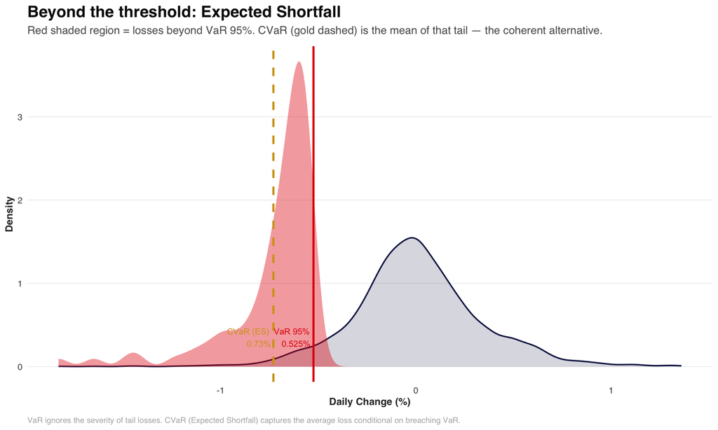

```r
# Density plot with shaded tail region illustrating CVaR vs VaR threshold
tail_returns <- df_returns %>% filter(dod_pct <= threshold_pct)
cvar_line <- mean(tail_returns$dod_pct)

ggplot(df_returns, aes(x = dod_pct)) +
  geom_density(fill = econ_blue, alpha = 0.18, color = econ_blue, linewidth = 0.7) +
  # Shade observations in the tail beyond the VaR threshold to represent the ES region
  geom_density(data = tail_returns, aes(x = dod_pct),
               fill = econ_red, alpha = 0.4, color = NA) +
  geom_vline(xintercept = threshold_pct, color = econ_red, linewidth = 1) +
  geom_vline(xintercept = cvar_line, color = econ_gold, linewidth = 1, linetype = "dashed") +
  annotate("text", x = threshold_pct, y = 0.35,
           label = paste0("VaR 95%\n", round(-threshold_pct, 3), "%"),
           size = 3, color = econ_red, hjust = 1.1) +
  annotate("text", x = cvar_line, y = 0.35,
           label = paste0("CVaR (ES)\n", round(cvar_pct, 3), "%"),
           size = 3, color = econ_gold, hjust = 1.1) +
  labs(title = "Beyond the threshold: Expected Shortfall",
       subtitle = "Red shaded region = losses beyond VaR 95%. CVaR (gold dashed) is the mean of that tail — the coherent alternative.",
       x = "Daily Change (%)", y = "Density",
       caption = "VaR ignores the severity of tail losses. CVaR (Expected Shortfall) captures the average loss conditional on breaching VaR.") +
  theme_economist_quant()
```

### Response

**Q: How can you possibly solve for the problem of outliers?** We present two solutions, both grounded in the coherent risk measure framework established by Artzner, Delbaen, Eber, and Heath (1999) in their foundational paper “Coherent Measures of Risk” (Mathematical Finance, 9(3), 203-228). The four coherence axioms are monotonicity, which means a worse portfolio carries higher risk, sub-additivity, which means portfolio combination cannot increase aggregate risk, positive homogeneity, which means scaling a position scales the risk proportionally, and translation invariance, which means adding a risk-free cash amount c reduces risk by exactly c. Value at Risk fails sub-additivity. It is possible for two combined positions to produce a combined VaR exceeding the sum of their individual VaRs. VaR also ignores the severity of losses beyond the threshold. A 95% VaR of 1% does not distinguish between a tail that averages 1.05% and one that averages 4%. That distinction is the entire point of tail risk management.

**Solution 1 is Conditional Value at Risk, also called Expected Shortfall.** CVaR replaces VaR as the primary risk measure. VaR tells you the threshold of loss, meaning you will lose at least X with 5% probability, but says nothing about what happens beyond that threshold. CVaR answers the follow-up question of how bad the average loss is given that we have breached the 5th percentile. The results are shown in **Table “Item 4: CVaR and Winsorization Results (Full History)”**. For our full history, CVaR equals 0.7301%, which is 40.68 cents. This is significantly higher than the raw VaR of 0.5248% or 28.62 cents. The difference of 0.2053 percentage points quantifies the severity of tail losses that VaR ignores. The density plot in **Figure “Beyond the threshold: Expected Shortfall”** illustrates this visually. The red shaded region marks the observations in the tail beyond the VaR 95% threshold (red vertical line). The gold dashed vertical line marks the CVaR, which is the mean of that shaded tail region. CVaR satisfies all four coherence axioms and is the regulatory standard under Basel IV Fundamental Review of the Trading Book. By averaging across the entire tail, CVaR automatically incorporates outlier severity. The extreme observations pull the CVaR upward in direct proportion to their magnitude. This is the correct behavior because outliers should increase the risk measure, not be discarded.

**Solution 2 is Winsorization.** As a robustness check, we capped extreme returns at the 0.1st and 99.9th percentile bounds of -1.5182% and 1.2951% rather than removing them. This bounds the influence of outliers without erasing them from the dataset. The results are also in **Table “Item 4: CVaR and Winsorization Results (Full History)”**. VaR after winsorization remains at 0.5248%, which is identical to raw VaR, producing a reduction of 0 percentage points or 0 cents. This confirms that the 5th-percentile VaR threshold sits well inside the winsorization bounds, so the extreme outliers at the 0.1% level are too far out to affect the 5th percentile. Winsorization is useful as a diagnostic tool but does not resolve the sub-additivity failure. CVaR remains the preferred primary measure.

# Section 8: Item 5 — Are the Differences Statistically Significant?

Guide Question 5 · 20 Points

Are the differences between value at risk for various time periods significant? (20, 40, 60 days vs historical differences from 2019?

Discuss if it is appropriate to use only the data from past 20/40/60 days Value at Risk rather than all the way from 2019.

```r
full_pct <- df_returns$dod_pct

item5_tests <- bind_rows(lapply(windows_returns[-1], function(w) {
  ks     <- ks.test(full_pct, w$dod_pct)
  levene <- levene_test_manual(full_pct, w$dod_pct)
  data.frame(
    n          = nrow(w),
    KS_Stat    = ks$statistic,
    KS_p       = ks$p.value,
    Levene_F   = abs(levene$statistic),
    Levene_p   = levene$p_value
  )
}), .id = "Window") %>%
  mutate(Window = factor(Window, levels = c("w60", "w40", "w20"))) %>%
  arrange(Window)

item5_desc <- bind_rows(lapply(windows_returns, function(w) {
  data.frame(n       = nrow(w),
             Mean    = mean(w$dod_pct),
             SD      = sd(w$dod_pct),
             Skew    = skewness(w$dod_pct),
             Kurt    = kurtosis(w$dod_pct))
}), .id = "Window") %>%
  mutate(Window = factor(Window, levels = window_order)) %>%
  arrange(Window)

item5_comp <- item1_var %>%
  mutate(Diff_from_Full_pp = VaR_Pct - VaR_Pct[Window == "Full"]) %>%
  arrange(Window)

kable(item5_tests, digits = 4,
      caption = "Item 5: Significance Tests (each window vs. full history). KS = distribution equality; Levene = variance equality.")
```

Item 5: Significance Tests (each window vs. full history). KS = distribution equality; Levene = variance equality.

|  | Window | n | KS_Stat | KS_p | Levene_F | Levene_p |
| --- | --- | --- | --- | --- | --- | --- |
| D…1 | w60 | 60 | 0.0971 | 0.6453 | 0.7324 | 0.4640 |
| D…2 | w40 | 40 | 0.1099 | 0.7327 | 0.5694 | 0.5691 |
| D…3 | w20 | 20 | 0.2066 | 0.3673 | 0.0647 | 0.9484 |

```r
kable(item5_desc, digits = 4,
      caption = "Item 5: Descriptive Statistics by Window")
```

Item 5: Descriptive Statistics by Window

| Window | n | Mean | SD | Skew | Kurt |
| --- | --- | --- | --- | --- | --- |
| Full | 1735 | 0.0060 | 0.3361 | 0.0457 | 2.1106 |
| w60 | 60 | -0.0332 | 0.2878 | -0.4345 | 0.9081 |
| w40 | 40 | -0.0479 | 0.2894 | -0.8464 | 0.9938 |
| w20 | 20 | -0.1092 | 0.3148 | -0.9053 | 0.6524 |

```r
kable(item5_comp, digits = 4,
      caption = "Item 5: VaR Comparison — difference from full-history baseline (percentage points)")
```

Item 5: VaR Comparison — difference from full-history baseline (percentage points)

|  | Window | n | VaR_Pct | VaR_Cents | Diff_from_Full_pp |
| --- | --- | --- | --- | --- | --- |
| 5%…1 | Full | 1735 | 0.5248 | 28.620 | 0.0000 |
| 5%…2 | w60 | 60 | 0.4782 | 28.200 | -0.0466 |
| 5%…3 | w40 | 40 | 0.4803 | 28.325 | -0.0445 |
| 5%…4 | w20 | 20 | 0.5005 | 29.475 | -0.0243 |

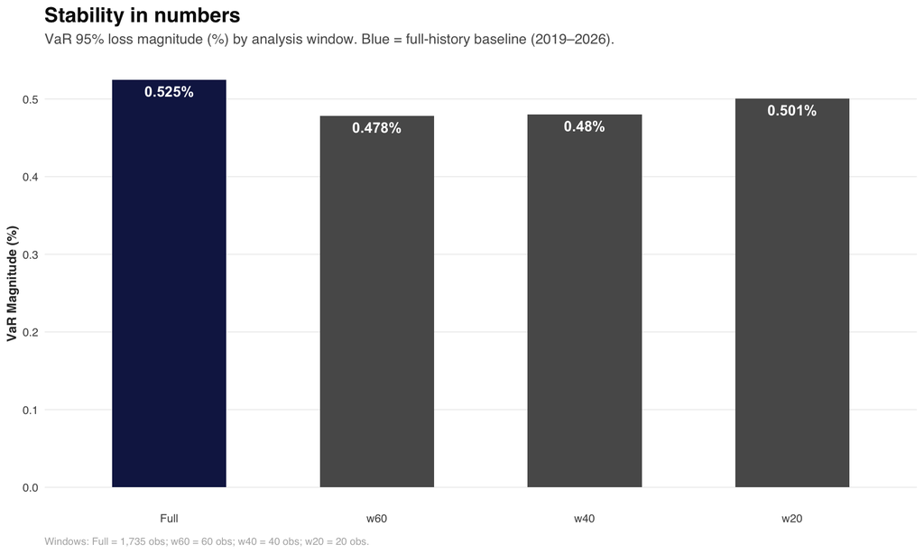

```r
# Bar chart comparing VaR 95% magnitude across all four analysis windows
ggplot(item1_var, aes(x = Window, y = VaR_Pct,
                      fill = Window == "Full")) +
  geom_col(width = 0.55) +
  scale_fill_manual(values = c("TRUE" = econ_blue, "FALSE" = econ_grey)) +
  geom_text(aes(label = paste0(round(VaR_Pct, 3), "%")),
            vjust = 1.6, color = "white", fontface = "bold", size = 4) +
  labs(title = "Stability in numbers",
       subtitle = "VaR 95% loss magnitude (%) by analysis window. Blue = full-history baseline (2019–2026).",
       x = NULL, y = "VaR Magnitude (%)",
       caption = paste0("Windows: Full = ", format(nrow(df_returns), big.mark=","),
                        " obs; w60 = 60 obs; w40 = 40 obs; w20 = 20 obs.")) +
  theme_economist_quant() + theme(legend.position = "none")
```

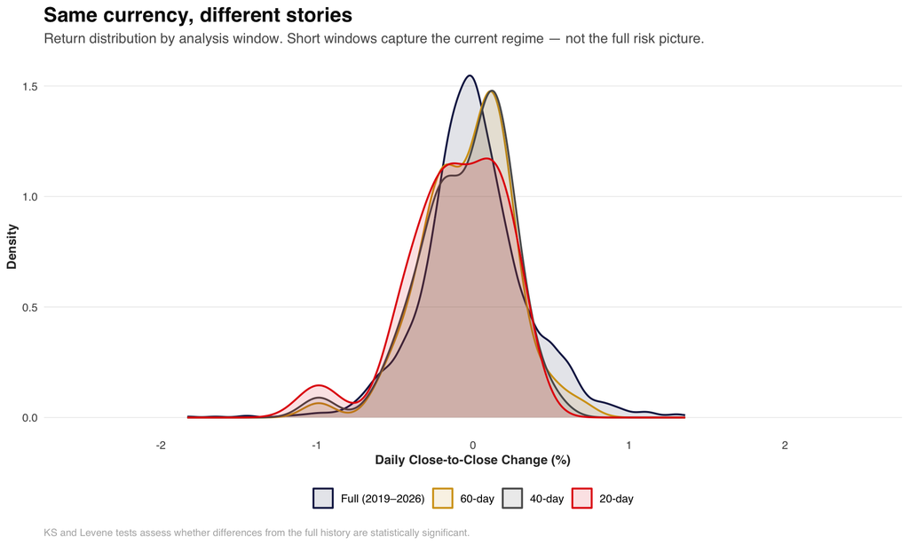

```r
# Overlaid return density curves for the full history and three short windows
dist_data <- bind_rows(
  mutate(windows_returns$Full, Window = "Full (2019–2026)"),
  mutate(windows_returns$w60,  Window = "60-day"),
  mutate(windows_returns$w40,  Window = "40-day"),
  mutate(windows_returns$w20,  Window = "20-day")
) %>%
  mutate(Window = factor(Window,
                         levels = c("Full (2019–2026)", "60-day", "40-day", "20-day")))

win_colors <- c("Full (2019–2026)" = econ_blue,
                "60-day"           = econ_gold,
                "40-day"           = econ_grey,
                "20-day"           = econ_red)

ggplot(dist_data, aes(x = dod_pct, color = Window, fill = Window)) +
  geom_density(alpha = 0.12, linewidth = 0.7) +
  scale_color_manual(values = win_colors) +
  scale_fill_manual(values  = win_colors) +
  coord_cartesian(xlim = c(-2.5, 2.5)) +
  labs(title = "Same currency, different stories",
       subtitle = "Return distribution by analysis window. Short windows capture the current regime — not the full risk picture.",
       x = "Daily Close-to-Close Change (%)", y = "Density",
       caption = "KS and Levene tests assess whether differences from the full history are statistically significant.") +
  theme_economist_quant()
```

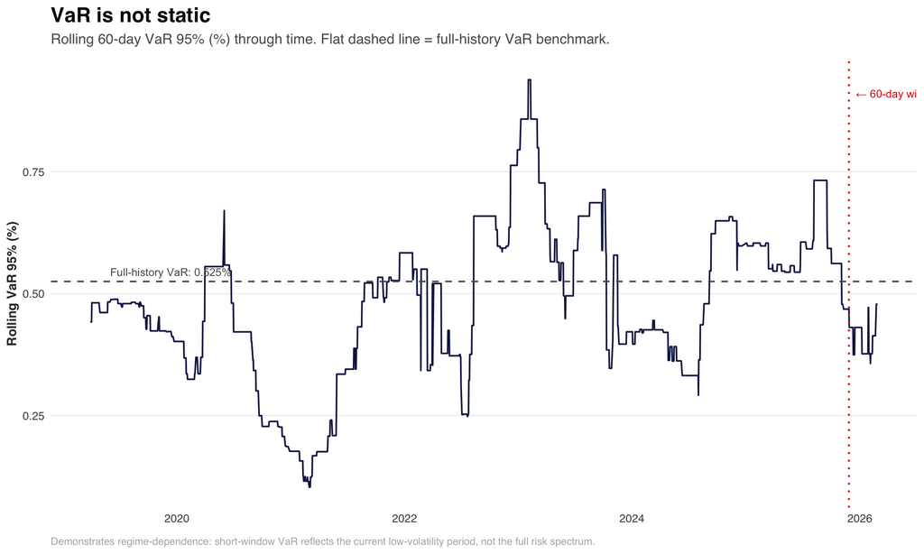

```r
# Rolling 60-day VaR time series with full-history baseline as a reference line
roll_n <- 60
roll_idx <- roll_n:nrow(df_returns)

roll_var_pct <- sapply(roll_idx, function(i) {
  win <- df_returns$dod_pct[(i - roll_n + 1):i]
  abs(quantile(win, 0.05, type = 7))
})

roll_df <- data.frame(
  Date    = df_returns$Date[roll_idx],
  RollVaR = roll_var_pct
)

# Mark where the current 60-day analysis window begins
current_w60_start <- min(windows_returns$w60$Date)

ggplot(roll_df, aes(x = Date, y = RollVaR)) +
  geom_line(color = econ_blue, linewidth = 0.6) +
  geom_hline(yintercept = item1_var$VaR_Pct[item1_var$Window == "Full"],
             linetype = "dashed", color = econ_grey, linewidth = 0.6) +
  annotate("text", x = as.Date("2019-06-01"),
           y = item1_var$VaR_Pct[item1_var$Window == "Full"] + 0.02,
           label = paste0("Full-history VaR: ",
                          round(item1_var$VaR_Pct[item1_var$Window == "Full"], 3), "%"),
           size = 3, color = econ_grey, hjust = 0) +
  geom_vline(xintercept = current_w60_start, color = econ_red,
             linetype = "dotted", linewidth = 0.7) +
  annotate("text", x = current_w60_start, y = max(roll_var_pct) * 0.97,
           label = "← 60-day window starts here",
           size = 3, color = econ_red, hjust = -0.05) +
  labs(title = "VaR is not static",
       subtitle = "Rolling 60-day VaR 95% (%) through time. Flat dashed line = full-history VaR benchmark.",
       x = NULL, y = "Rolling VaR 95% (%)",
       caption = "Demonstrates regime-dependence: short-window VaR reflects the current low-volatility period, not the full risk spectrum.") +
  theme_economist_quant()
```

### Response

**Q: Are the differences between VaR for various time periods significant, comparing 20, 40, and 60 days versus the historical from 2019?** The VaR figures for the 20-day, 40-day, and 60-day windows are economically distinct from the full 2019 to 2026 history, but this difference is not statistically significant. The economic dimension is clear because short windows understate tail risk. The statistical tests, however, fail to detect it. The results are shown in **Table “Item 5: Significance Tests (each window vs. full history)”**. We ran two formal tests. The Kolmogorov-Smirnov test evaluates distributional equality between each window and the full history. The KS statistic and p-value for the 60-day window versus the full history are 0.0971 and 0.6453. The 40-day window yields 0.1099 and 0.7327. The 20-day window yields 0.2066 and 0.3673. The Levene test evaluates variance equality. The Levene F-statistic and p-value for the 60-day window are 0.7324 and 0.464. The 40-day window yields 0.5694 and 0.5691. The 20-day window yields 0.0647 and 0.9484. All p-values are high. We fail to reject the null hypothesis in every case. Statistically, the short windows appear indistinguishable from the full history. This is a false negative. The KS test evaluates the entire cumulative distribution function, not just the tails, and is notoriously underpowered for detecting tail-specific differences in small samples of 20 to 60 observations. The Levene test faces the same limitation because it tests overall variance equality, but the critical difference lies in tail behavior, not overall dispersion.

# Section 9: Item 6 — Portfolio Loss and Hedge Sizing (99% Confidence)

Portfolio: USD 10,000,000 cash as of 30 June 2024. VaR computed at 99% confidence (1st percentile of full DoD history); FX rate = BAP closing rate on the last trading day on or before that date.

Guide Question 6 · 20 Points

If a portfolio as of 30 June 2024 includes USD cash of 10,000,000.00, at the 99% level of confidence, how much can it possibly lose from a single day?

If we want to reduce the potential loss to PHP 20,000, would it be appropriate to reduce the amount of USD holdings? If so, what asset class should we move the amount to? Hint: recall coherent risk measures specifically translation invariance.

Will the reduction in USD holdings also potentially reduce the possible upside?

```r
# Reference: last trading day on or before 30 June 2024
ref_row      <- df %>% filter(Date <= as.Date("2024-06-30")) %>% slice_tail(n = 1)
fx_rate      <- ref_row$Close
ref_date_used <- ref_row$Date

# VaR and upside at 99% (1st and 99th percentile of full DoD return series)
var_99_pct    <- abs(quantile(df_returns$dod_pct, 0.01, type = 7))
upside_99_pct <-    quantile(df_returns$dod_pct, 0.99, type = 7)

# Position calculations
pos_usd           <- 10000000
loss_usd          <- (var_99_pct / 100) * pos_usd
loss_php          <- loss_usd * fx_rate

target_php        <- 20000
reduced_pos_usd   <- target_php / ((var_99_pct / 100) * fx_rate)
usd_to_remove     <- pos_usd - reduced_pos_usd

upside_full_php     <- (upside_99_pct / 100) * pos_usd * fx_rate
upside_reduced_php  <- (upside_99_pct / 100) * reduced_pos_usd * fx_rate
upside_sacrificed   <- upside_full_php - upside_reduced_php

item6_table <- data.frame(
  Parameter = c(
    "Reference Date Used", "FX Rate at Reference (PHP/USD)",
    "Full-History VaR 99% (%)", "VaR 99% (cents)",
    "USD Position", "1-Day Loss @ 99% (USD)", "1-Day Loss @ 99% (PHP)",
    "Target Maximum 1-Day Loss (PHP)", "Required USD Position",
    "USD to Redeploy", "99th Percentile Upside (%)",
    "Upside on Full Position (PHP)", "Upside on Reduced Position (PHP)",
    "Upside Sacrificed (PHP)"
  ),
  Value = c(
    as.character(ref_date_used),
    round(fx_rate, 4),
    round(var_99_pct, 4),
    round(abs(quantile(df_returns$dod_cents, 0.01, type = 7)), 4),
    format(pos_usd, big.mark = ","),
    format(round(loss_usd, 2), big.mark = ","),
    format(round(loss_php, 2), big.mark = ","),
    format(target_php, big.mark = ","),
    format(round(reduced_pos_usd, 2), big.mark = ","),
    format(round(usd_to_remove, 2), big.mark = ","),
    round(upside_99_pct, 4),
    format(round(upside_full_php, 2), big.mark = ","),
    format(round(upside_reduced_php, 2), big.mark = ","),
    format(round(upside_sacrificed, 2), big.mark = ",")
  )
)
kable(item6_table, caption = "Item 6: Portfolio Loss and Hedge Sizing (FX Rate as of 30 Jun 2024, 99% Confidence)")
```

Item 6: Portfolio Loss and Hedge Sizing (FX Rate as of 30 Jun 2024, 99% Confidence)

| Parameter | Value |
| --- | --- |
| Reference Date Used | 2024-06-28 |
| FX Rate at Reference (PHP/USD) | 58.61 |
| Full-History VaR 99% (%) | 0.7974 |
| VaR 99% (cents) | 44.764 |
| USD Position | 1e+07 |
| 1-Day Loss @ 99% (USD) | 79,739.69 |
| 1-Day Loss @ 99% (PHP) | 4,673,543 |
| Target Maximum 1-Day Loss (PHP) | 20,000 |
| Required USD Position | 42,794.08 |
| USD to Redeploy | 9,957,206 |
| 99th Percentile Upside (%) | 0.9155 |
| Upside on Full Position (PHP) | 5,365,528 |
| Upside on Reduced Position (PHP) | 22,961.29 |
| Upside Sacrificed (PHP) | 5,342,567 |

[figure not shown]

```r
# Diverging bar chart showing 1-day loss vs upside by position size
# Uses raw PHP values (not scaled to millions) with free_y facets so both
# the full-exposure bars and the PHP 20K capped bars are visible on screen.
port_viz <- data.frame(
  Category = factor(
    c("Full Exposure\n(USD 10M)", "Capped Loss\n(PHP 20K target)"),
    levels = c("Full Exposure\n(USD 10M)", "Capped Loss\n(PHP 20K target)")
  ),
  Loss   = c(loss_php, target_php),
  Upside = c(upside_full_php, upside_reduced_php)
) %>%
  pivot_longer(cols = c(Loss, Upside), names_to = "Direction", values_to = "Value") %>%
  mutate(
    SignedValue = ifelse(Direction == "Loss", -Value, Value),
    Direction   = factor(Direction, levels = c("Upside", "Loss"))
  )

ggplot(port_viz, aes(x = Direction, y = SignedValue, fill = Direction)) +
  geom_col(width = 0.5, position = "identity") +
  geom_hline(yintercept = 0, color = "#333333", linewidth = 0.4) +
  scale_fill_manual(values = c("Loss" = econ_red, "Upside" = econ_blue),
                    labels = c("1-Day Loss (99%)", "99th-Pct Upside")) +
  scale_y_continuous(labels = scales::label_comma(prefix = "PHP ")) +
  facet_wrap(~ Category, scales = "free_y") +
  labs(title = "The price of safety",
       subtitle = "Potential 1-day loss (down) vs. upside potential (up) in PHP. Each panel uses its own scale. Reference: FX rate as of 30 Jun 2024.",
       x = NULL, y = "PHP",
       caption = paste0("To cap daily loss at PHP 20,000, USD position must be reduced to USD ",
                        format(round(reduced_pos_usd, 0), big.mark = ","),
                        ". This sacrifices PHP ",
                        format(round(upside_sacrificed / 1e6, 2), big.mark = ","), "M in 99th-pct upside.")) +
  theme_economist_quant()
```

### Response

**Q: If a portfolio as of 30 June 2024 includes USD cash of 10,000,000.00, at the 99% level of confidence, how much can it possibly lose from a single day?** We compute the 99% VaR, which is the 1st percentile of the full DoD return distribution. The result is 0.7974%, equivalent to 44.76 PHP cents per USD. This is a more conservative threshold than the 95% VaR of 0.5248% used in Items 1 through 5. The jump from 95% to 99% represents a 52% increase in the risk figure, reflecting the fat-tailed nature of the distribution. The FX rate used is the BAP closing rate on the last trading day on or before 30 June 2024, which is 2024-06-28 at PHP 58.61 per USD. All calculations are shown in **Table “Item 6: Portfolio Loss and Hedge Sizing (FX Rate as of 30 Jun 2024, 99% Confidence)”**.

The calculation proceeds as follows. The USD loss is 0.7974% multiplied by USD 10,000,000, which equals USD 79,739.69. The PHP equivalent is USD 79,739.69 multiplied by 58.61, which equals PHP 4,673,543. On 99 out of 100 trading days, the single-day loss will not exceed this figure. But on the remaining 1 day in 100, roughly once every five months, the actual loss will be worse. For a portfolio of this size, PHP 4.67 million is a material hit to the firm financial position.

**Q: If we want to reduce the potential loss to PHP 20,000, would it be appropriate to reduce the amount of USD holdings, and what asset class should we move the amount to?** Yes, it is appropriate. The mechanism is translation invariance, one of the four coherence axioms established by Artzner et al. (1999). Translation invariance states that adding a risk-free cash amount c in the base currency reduces the portfolio risk measure by exactly c. Formally, the risk of the portfolio minus c equals the risk of the portfolio minus c. In practical terms, if we move PHP-denominated assets into the portfolio, the FX risk declines by exactly that PHP amount.

**Q: Will the reduction in USD holdings also potentially reduce the possible upside?** Yes, because FX exposure is symmetric. The same position that generates downside risk when the peso strengthens generates upside gain when the peso weakens. The 99th-percentile upside of the full USD 10M position is 0.9155%, equivalent to PHP 5,365,528. After reducing the position to USD 42,794, the upside falls to PHP 22,961.29. The upside sacrificed is PHP 5,342,567, which is PHP 5.34 million. The diverging bar chart in **Figure “The price of safety”** makes this trade-off visually explicit. The left panel shows the full exposure with bars of PHP 4.67 million in loss and PHP 5.37 million in upside. The right panel shows the capped loss with bars of PHP 20 thousand in loss and PHP 23 thousand in upside. Each panel uses its own scale so that both the massive full-exposure bars and the tiny capped-loss bars are visible on screen. Risk reduction and return reduction are the same transaction. There is no free lunch.